# FInal_Project

許右瑄

2017年6月18日

歷年各院交換生人數變化

從圖中可以發現，以管理學院的交換人數成長最快，在2015年交換生人數已高達350人，占總額的四分之一；其次則為文學院及社會科學院，約為230人左右，以上三個學院就囊括了總額的六成以上；其他學院多維持在20至60人左右。

```r
library(ggplot2)
library(plotly)
require(stats)

setwd("C:/Users/asus/Dropbox/R Language Thursday/HW04")
rawdata <- read.csv("exchange_students.csv",header = TRUE,encoding = "UTF-8", sep=",")


yearLength <- length(rawdata$year)
firstyear <- rawdata$year[1]
lastyear <- rawdata$year[yearLength]
n <- lastyear - firstyear +1
alltype <- colnames(rawdata)

CollegeId <- c(3:13)
newTable <- data.frame()
for (i in 2:n)
{
  year <- as.matrix(rep(rawdata$year[i],length(rawdata[i,CollegeId])))
  people = as.matrix(as.numeric(rawdata[i,CollegeId]))
  type = as.matrix(as.character(alltype[CollegeId]))
  temp = cbind(year, type, people)
  newTable = rbind(newTable, temp)
}

names(newTable) = c('year', 'College', 'people')
newTable = newTable[with(newTable, order(College)),]
rownames(newTable) <- 1:nrow(newTable)

p <- plot_ly(data = newTable[,1:3], x = ~year,
             y = ~people, color = ~College, main="甇瑕僑??鈭斗??犖?") %>%
  add_lines( yaxis = list(range = c(0,10)))
p
```

[output not shown]

[interactive chart not shown]

建立2007至2013年各學院的交換生人數、合約數量及英語授課數量的data frame

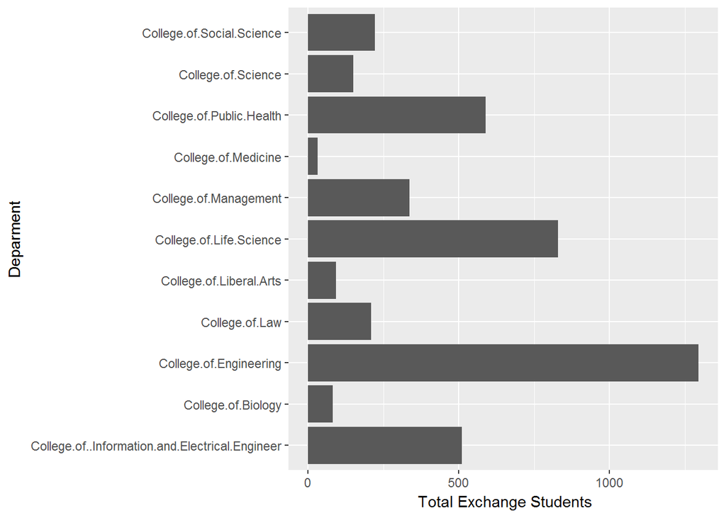

```r
setwd("C:/Users/asus/Dropbox/R Language Thursday/HW04")
english_course <- read.csv("english_course.csv", sep=",", header=TRUE)
number_of_exchange_students <- read.csv("exchange_students.csv", sep=",", header=TRUE)
contract <- read.csv("contract.csv", sep=",", header=TRUE)



#建立data frame
n <- ncol(english_course)
Newtable <- data.frame()

for (i in 3:n){
  table <- as.matrix(english_course[1:7,i])
  table2 <- as.matrix(number_of_exchange_students[15:21,i])
  table3 <- as.matrix(contract[28:34,i])
  temp <- cbind(table, table2,table3)
  Newtable <- rbind(temp,Newtable)
}

data <- data.frame(rep(colnames(english_course)[3:13],each=7),Newtable)
colnames(data) <- c("department","English_courses", "Exchange_students","Contracts")


#交換生人數及英語授課數量加總
ggplot(data=data, aes(y=Exchange_students, x=department))+ geom_bar(stat="identity") +coord_flip() + labs(x="Deparment", y=" Total Exchange Students")
```

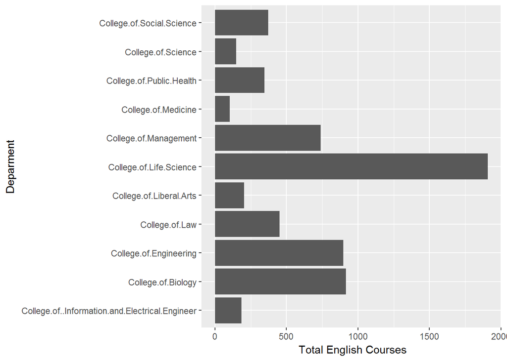

```r
ggplot(data=data, aes(y=data[,2], x=department))+ geom_bar(stat="identity") +coord_flip() + labs(x="Deparment", y=" Total English Courses")
```

```r
#歷年平均交換生人數及英語授課數量
mean1 <- tapply(data[,2], data[,1],mean)
mean2 <- tapply(data[,3], data[,1],mean)

#平均一位交換生可以選擇的英語課程數量
mean1/mean2
```

```
## College.of..Information.and.Electrical.Engineer
##                                       0.3607843
##                              College.of.Biology
##                                      11.0240964
##                          College.of.Engineering
##                                       0.6926641
##                                  College.of.Law
##                                       2.1523810
##                         College.of.Liberal.Arts
##                                       2.1827957
##                         College.of.Life.Science
##                                       2.2987952
##                           College.of.Management
##                                       2.1958457
##                             College.of.Medicine
##                                       3.1515152
##                        College.of.Public.Health
##                                       0.5891341
##                              College.of.Science
##                                       0.9866667
##                       College.of.Social.Science
##                                       1.6756757
```

推測交換生選擇來台原因： 1. 因為學校提供英語授課，所以語言障礙的門檻並不高，故選擇來台灣交換 2. 因校方合約問題，雙方簽約並配給固定名額，因此再現有機會下選擇來台交換 3. 因台灣政經穩定，並不常發生恐怖攻擊或政治動亂，選擇來台灣也較安全 4. 因中國經濟快速發展，使得越來越多人希望學習中文，因此選擇台灣來學習中文 5. 因台灣經濟發展良好，交通便利且生活機能良好，來台灣並不會遇到生活不便的問題 6. 受到來台觀光人數漸增，打開台灣在國外的知名度，外國學生因而想來台灣交換順便參觀

先觀察這幾項變數之間的相關性，可以發現幾項重點： 1.外國觀光人數與交換生人數確實有明顯正相關 2.而和約束量及英語授課數量也和交換生人數呈明顯正相關 3.發現台灣經濟發展與其他變數關係並不大，僅與中國經濟狀況及政經穩定度呈現正相關 4.中國經濟成長反倒與觀光人數、交換生數等成負相關 5.政經穩定度則與其他變數均無顯著關係

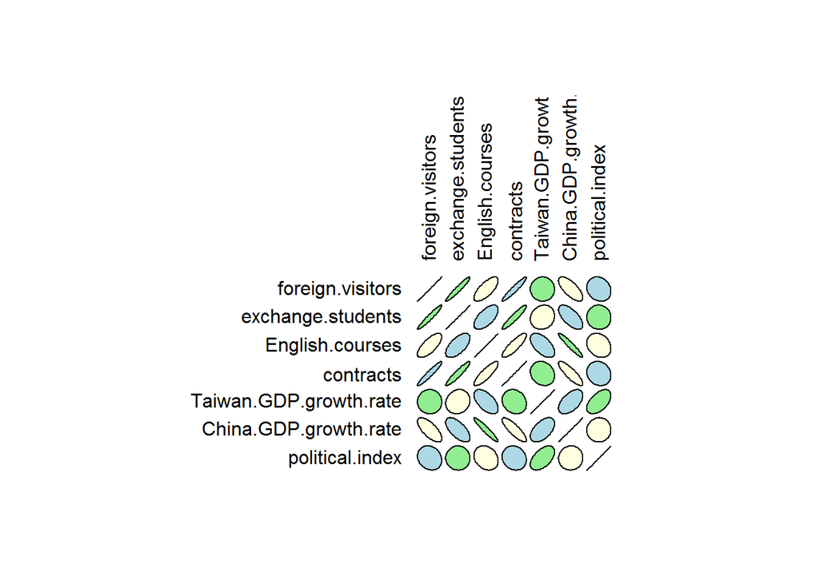

```r
setwd("C:/Users/asus/Dropbox/R Language Thursday/FINAL")
library(ellipse)

#data clearing
rawdata <- read.csv("rawdata.csv", sep=",", header=TRUE)
rawdata2 <- rawdata[,2:8]
rownames(rawdata2) <- rawdata[,1]

rawdata2[,1] <- as.numeric(as.character(rawdata[,2]))
rawdata2[,2] <- as.numeric(rawdata[,3])
rawdata2[,3] <- as.numeric(rawdata[,4])
rawdata2[,4] <- as.numeric(rawdata[,5])
rawdata2[,5] <- as.numeric(rawdata[,6])
rawdata2[,6] <- as.numeric(rawdata[,7])
rawdata2[,7] <- as.numeric(rawdata[,8])
# summary
data2 <- rawdata2[28:34,1:7]
corr <- cor(data2)
plotcorr(corr, col=rep(c("lightblue", "lightgreen", "lightyellow")))
```

```r
summary(data2)
```

```
##  foreign.visitors  exchange.students English.courses   contracts
##  Min.   :3716063   Min.   :290.0     Min.   :785.0   Min.   :237.0
##  1st Qu.:4120096   1st Qu.:354.5     1st Qu.:869.0   1st Qu.:322.5
##  Median :5567277   Median :672.0     Median :887.0   Median :369.0
##  Mean   :5562681   Mean   :586.6     Mean   :895.7   Mean   :366.9
##  3rd Qu.:6699477   3rd Qu.:760.0     3rd Qu.:949.0   3rd Qu.:415.5
##  Max.   :8016280   Max.   :915.0     Max.   :962.0   Max.   :486.0
##  Taiwan.GDP.growth.rate China.GDP.growth.rate political.index
##  Min.   :-1.570         Min.   : 7.80         Min.   :0.2047
##  1st Qu.: 1.380         1st Qu.: 8.55         1st Qu.:0.2060
##  Median : 2.200         Median : 9.50         Median :0.2081
##  Mean   : 3.479         Mean   : 9.83         Mean   :0.2086
##  3rd Qu.: 5.165         3rd Qu.:10.11         3rd Qu.:0.2104
##  Max.   :10.630         Max.   :14.20         Max.   :0.2146
```

接著就依照上述6個變數去做回歸檢定，並用partial F test刪去不重要的變數可以發現，影響最大的變數為何約數量及英語授課數量。

可以得出以下回歸：交換生人數=-12.548 + 1.398 x contracts + 0.259 x English_courses

合理的是，合約數量的增加對於交換生人數也會有正向的影響，畢竟學校雙方簽訂合約，通常就會配給一定的名額可供兩邊學生互相交換，因此合約越多的話，理當交換生人數也會跟著增加；此外，英語授課數量的增加也會造成交換生人數的增加，合理推測，當學校希望能夠招收更多交換學生的情況下，勢必也必須開設夠多的英語課程數量，否則吸引來的交換學生可能就僅侷限在懂中文或想學中文的交換學生，因而降低外國學生來台交換的意願。

```r
# F test for linear regression model
newdata <- cbind(data,data2[,c(1,5,6,7)])
anova(m0 <- lm(newdata[,3]~ Contracts, data=newdata))
```

```
## Analysis of Variance Table
##
## Response: newdata[, 3]
##           Df Sum Sq Mean Sq F value    Pr(>F)
## Contracts  1 186206  186206  119.98 < 2.2e-16 ***
## Residuals 75 116393    1552
## ---
## Signif. codes:  0 '***' 0.001 '**' 0.01 '*' 0.05 '.' 0.1 ' ' 1
```

```r
anova(m1 <- lm(newdata[,3]~ Contracts+ English_courses, data=newdata))
```

```
## Analysis of Variance Table
##
## Response: newdata[, 3]
##                 Df Sum Sq Mean Sq F value    Pr(>F)
## Contracts        1 186206  186206 153.230 < 2.2e-16 ***
## English_courses  1  26468   26468  21.781 1.331e-05 ***
## Residuals       74  89925    1215
## ---
## Signif. codes:  0 '***' 0.001 '**' 0.01 '*' 0.05 '.' 0.1 ' ' 1
```

```r
anova(m2 <- lm(newdata[,3]~ foreign.visitors+ Contracts+ English_courses+ political.index, data=newdata))
```

```
## Analysis of Variance Table
##
## Response: newdata[, 3]
##                  Df Sum Sq Mean Sq  F value    Pr(>F)
## foreign.visitors  1  23313   23313  18.6770 4.882e-05 ***
## Contracts         1 163018  163018 130.5989 < 2.2e-16 ***
## English_courses   1  26372   26372  21.1276 1.790e-05 ***
## political.index   1     23      23   0.0185    0.8921
## Residuals        72  89873    1248
## ---
## Signif. codes:  0 '***' 0.001 '**' 0.01 '*' 0.05 '.' 0.1 ' ' 1
```

```r
anova(m3 <- lm(newdata[,3]~ foreign.visitors+ Contracts+ English_courses+Taiwan.GDP.growth.rate+ political.index, data=newdata))
```

```
## Analysis of Variance Table
##
## Response: newdata[, 3]
##                        Df Sum Sq Mean Sq  F value    Pr(>F)
## foreign.visitors        1  23313   23313  18.5173 5.290e-05 ***
## Contracts               1 163018  163018 129.4823 < 2.2e-16 ***
## English_courses         1  26372   26372  20.9470 1.958e-05 ***
## Taiwan.GDP.growth.rate  1    446     446   0.3546    0.5534
## political.index         1     61      61   0.0482    0.8269
## Residuals              71  89389    1259
## ---
## Signif. codes:  0 '***' 0.001 '**' 0.01 '*' 0.05 '.' 0.1 ' ' 1
```

```r
anova(m4 <- lm(newdata[,3]~ foreign.visitors+ Contracts+ English_courses+Taiwan.GDP.growth.rate+ China.GDP.growth.rate + political.index, data=newdata))
```

```
## Analysis of Variance Table
##
## Response: newdata[, 3]
##                        Df Sum Sq Mean Sq  F value    Pr(>F)
## foreign.visitors        1  23313   23313  18.2718 5.941e-05 ***
## Contracts               1 163018  163018 127.7654 < 2.2e-16 ***
## English_courses         1  26372   26372  20.6692 2.227e-05 ***
## Taiwan.GDP.growth.rate  1    446     446   0.3499    0.5561
## China.GDP.growth.rate   1    103     103   0.0811    0.7766
## political.index         1     32      32   0.0250    0.8749
## Residuals              70  89314    1276
## ---
## Signif. codes:  0 '***' 0.001 '**' 0.01 '*' 0.05 '.' 0.1 ' ' 1
```

```r
lapply(list(m0,m1,m2,m3,m4),summary)
```

```
## [[1]]
##
## Call:
## lm(formula = newdata[, 3] ~ Contracts, data = newdata)
##
## Residuals:
##     Min      1Q  Median      3Q     Max
## -66.499 -22.579  -8.928  12.314 115.468
##
## Coefficients:
##             Estimate Std. Error t value Pr(>|t|)
## (Intercept)   4.0351     6.5660   0.615    0.541
## Contracts     1.5302     0.1397  10.954   <2e-16 ***
## ---
## Signif. codes:  0 '***' 0.001 '**' 0.01 '*' 0.05 '.' 0.1 ' ' 1
##
## Residual standard error: 39.39 on 75 degrees of freedom
## Multiple R-squared:  0.6154, Adjusted R-squared:  0.6102
## F-statistic:   120 on 1 and 75 DF,  p-value: < 2.2e-16
##
##
## [[2]]
##
## Call:
## lm(formula = newdata[, 3] ~ Contracts + English_courses, data = newdata)
##
## Residuals:
##     Min      1Q  Median      3Q     Max
## -68.776 -22.201  -1.863  11.914  97.578
##
## Coefficients:
##                  Estimate Std. Error t value Pr(>|t|)
## (Intercept)     -12.54792    6.81060  -1.842   0.0694 .
## Contracts         1.39791    0.12683  11.022  < 2e-16 ***
## English_courses   0.25938    0.05558   4.667 1.33e-05 ***
## ---
## Signif. codes:  0 '***' 0.001 '**' 0.01 '*' 0.05 '.' 0.1 ' ' 1
##
## Residual standard error: 34.86 on 74 degrees of freedom
## Multiple R-squared:  0.7028, Adjusted R-squared:  0.6948
```

[output cut: 65 more lines]

```
## Coefficients:
##                          Estimate Std. Error t value Pr(>|t|)
## (Intercept)            -2.118e+02  1.153e+03  -0.184    0.855
## foreign.visitors        2.671e-06  1.374e-05   0.194    0.846
## Contracts               1.414e+00  1.412e-01  10.016 3.74e-15 ***
## English_courses         2.601e-01  5.701e-02   4.563 2.10e-05 ***
## Taiwan.GDP.growth.rate -5.995e-01  5.924e+00  -0.101    0.920
## China.GDP.growth.rate   3.216e+00  1.329e+01   0.242    0.810
## political.index         7.393e+02  4.679e+03   0.158    0.875
## ---
## Signif. codes:  0 '***' 0.001 '**' 0.01 '*' 0.05 '.' 0.1 ' ' 1
##
## Residual standard error: 35.72 on 70 degrees of freedom
## Multiple R-squared:  0.7048, Adjusted R-squared:  0.6795
## F-statistic: 27.86 on 6 and 70 DF,  p-value: < 2.2e-16
```

```r
#Partial F test
anova(m4, m3)
```

```
## Analysis of Variance Table
##
## Model 1: newdata[, 3] ~ foreign.visitors + Contracts + English_courses +
##     Taiwan.GDP.growth.rate + China.GDP.growth.rate + political.index
## Model 2: newdata[, 3] ~ foreign.visitors + Contracts + English_courses +
##     Taiwan.GDP.growth.rate + political.index
##   Res.Df   RSS Df Sum of Sq      F Pr(>F)
## 1     70 89314
## 2     71 89389 -1   -74.706 0.0586 0.8095
```

```r
anova(m3, m2)
```

```
## Analysis of Variance Table
##
## Model 1: newdata[, 3] ~ foreign.visitors + Contracts + English_courses +
##     Taiwan.GDP.growth.rate + political.index
## Model 2: newdata[, 3] ~ foreign.visitors + Contracts + English_courses +
##     political.index
##   Res.Df   RSS Df Sum of Sq      F Pr(>F)
## 1     71 89389
## 2     72 89873 -1   -484.01 0.3844 0.5372
```

```r
anova(m2, m1)
```

```
## Analysis of Variance Table
##
## Model 1: newdata[, 3] ~ foreign.visitors + Contracts + English_courses +
##     political.index
## Model 2: newdata[, 3] ~ Contracts + English_courses
##   Res.Df   RSS Df Sum of Sq      F Pr(>F)
## 1     72 89873
## 2     74 89925 -2   -52.166 0.0209 0.9793
```

```r
anova(m1, m0)
```

```
## Analysis of Variance Table
##
## Model 1: newdata[, 3] ~ Contracts + English_courses
## Model 2: newdata[, 3] ~ Contracts
##   Res.Df    RSS Df Sum of Sq      F    Pr(>F)
## 1     74  89925
## 2     75 116393 -1    -26468 21.781 1.331e-05 ***
## ---
## Signif. codes:  0 '***' 0.001 '**' 0.01 '*' 0.05 '.' 0.1 ' ' 1
```

```r
summary(m1)
```

```
##
## Call:
## lm(formula = newdata[, 3] ~ Contracts + English_courses, data = newdata)
##
## Residuals:
##     Min      1Q  Median      3Q     Max
## -68.776 -22.201  -1.863  11.914  97.578
##
## Coefficients:
##                  Estimate Std. Error t value Pr(>|t|)
## (Intercept)     -12.54792    6.81060  -1.842   0.0694 .
## Contracts         1.39791    0.12683  11.022  < 2e-16 ***
## English_courses   0.25938    0.05558   4.667 1.33e-05 ***
## ---
## Signif. codes:  0 '***' 0.001 '**' 0.01 '*' 0.05 '.' 0.1 ' ' 1
##
## Residual standard error: 34.86 on 74 degrees of freedom
## Multiple R-squared:  0.7028, Adjusted R-squared:  0.6948
## F-statistic: 87.51 on 2 and 74 DF,  p-value: < 2.2e-16
```

[figure not shown]

```r
#英語授課數量與交換生人數關係，y=exchange students, x=English courses
ggplot(data=data, aes(group=department, x=data[,3], y= data[,2])) + geom_point() + stat_smooth(method="lm", se=F)+stat_smooth(aes(group=department, x=data[,3], y= data[,2]),method="lm", se=F)+facet_grid(.~department)+labs(x="English course", y="Exchange student")
```

[figure not shown]

```r
#英語授課數量與合約數關係，y=English courses, x=contracts
ggplot(data=data, aes(group=department, x=data[,4], y= data[,2])) + geom_point() + stat_smooth(method="lm", se=F)+stat_smooth(aes(group=department, x=data[,4], y= data[,2]),method="lm", se=F)+facet_grid(.~department)+labs(x="English course", y="Contracts")
```

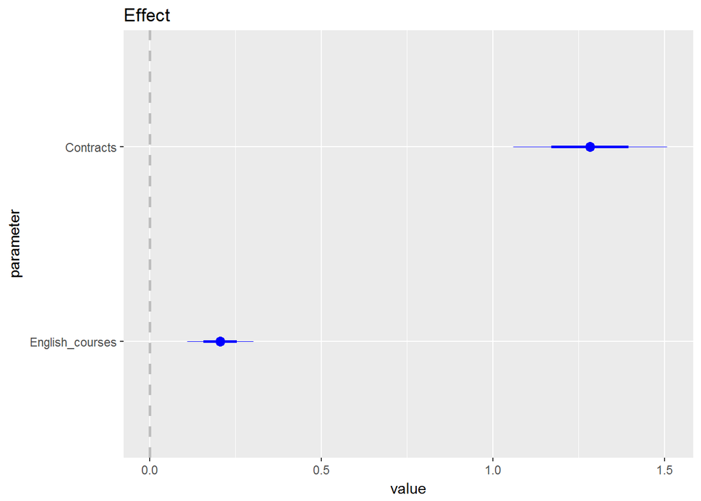

```r
#合約數量及英語授課數量對交換生人數的效果
library(coefplot)
effect <- lm(data=data, Exchange_students~English_courses+Contracts-1)
coefplot(effect, xlab="value", "parameter", title="Effect")
```